# Titanic

```r
library(knitr)
library(tidyverse)
library(titanic)
```

Man könnte hier zuerst die Wahrscheinlichkeit eines Mannes zu überleben berechnen; danach berechnen wir ob es einen siginifkanten Unterschied des relativen Anteils der Männer im Vergleich zu dem der Frauen gibt. Anschließen schauen wir uns die Kinder an.

```r
df <- titanic::titanic_train %>% select(Survived, Sex, Age)
```

Haben Frauen eine signifikant höhere Überlebenschance als Männer?

```r
prop.table(table(df$Survived, df_filtered$Sex))
```

[output not shown]

Wieviel Männer haben überlebt?

```r
df %>% filter(Sex == 'male') %>% summarise(n=n()) %>% as.numeric() -> nb_male
df %>% filter(Sex == 'male' & Survived == '1') %>% summarise(n=n()) %>% as.numeric() -> nb_male_survived
```

```r
df %>% filter(Sex == 'female') %>% summarise(n=n()) %>% as.numeric() -> nb_female
df %>% filter(Sex == 'female' & Survived == '1') %>% summarise(n=n()) %>% as.numeric() -> nb_female_survived
```

```r
prop.test(x = c(nb_female_survived, nb_male_survived), n=c(nb_female, nb_male), alternative = 'greater')
```

```
    2-sample test for equality of proportions with continuity correction

data:  c(nb_female_survived, nb_male_survived) out of c(nb_female, nb_male)
X-squared = 260.72, df = 1, p-value < 2.2e-16
alternative hypothesis: greater
95 percent confidence interval:
 0.5020113 1.0000000
sample estimates:
   prop 1    prop 2
0.7420382 0.1889081
```

```r
ftable(Titanic)
```

```
                   Survived  No Yes
Class Sex    Age
1st   Male   Child            0   5
             Adult          118  57
      Female Child            0   1
             Adult            4 140
2nd   Male   Child            0  11
             Adult          154  14
      Female Child            0  13
             Adult           13  80
3rd   Male   Child           35  13
             Adult          387  75
      Female Child           17  14
             Adult           89  76
Crew  Male   Child            0   0
             Adult          670 192
      Female Child            0   0
             Adult            3  20
```

Aus diesem Table würde ich dann die nötigen Werte für den Proportionstest rausnehmen.

Für Kinder geht das analog. Man muss sich nur überlegen was es heißt ein Kind zu sein. Spricht bei welchem Alter man tn threshold einzieht.

## Mosaic Plot

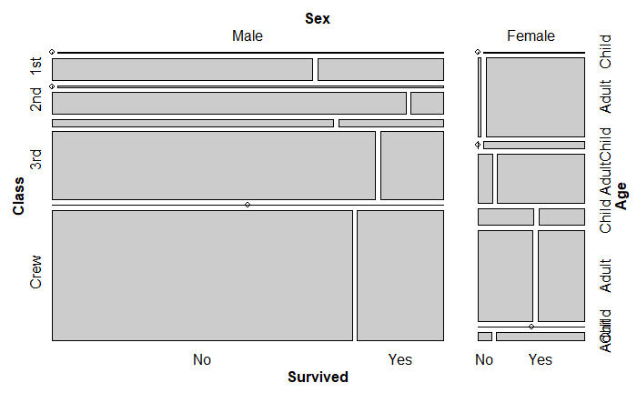

# Genontologieanalyse

```r
n <- 696
nb_krebs <- 413
```

Hier ist Frage nicht ganz korrekt gestellt. Es wird so interpretiert, dass wir zuerst einen Punktschätzer der Proportion ermitteln um dananch das Konfidenzintervall it einer gewissen statistischen Sicherheit anzugeben.

```r
p_hat <- nb_krebs/n
```

```r
# Set CI alpha level (1-alpha/2)*100%
alpha = 0.05
# Calculate the critical z-score
z = qnorm(1-alpha/2)
# Compute the CI
(conf_upper <- p_hat + z*sqrt(p_hat*(1-p_hat)/n))
```

```
[1] 0.6298832
```

```r
(conf_lower <- p_hat - z*sqrt(p_hat*(1-p_hat)/n))
```

```
[1] 0.5568984
```

NB: Vielleicht finde ich hier noch eine einfachere Möglichkeit, das zu berechnen. Es kann leicht sein, dass das CI als Nebenergebnis bei einem anderen Test abfällt.

für das 99% Intervall muss man nur den alpha Wert anpassen.

```r
prop.test(x = nb_krebs, n = n, p = 0.55, alternative = 'two.sided')
```

```
    1-sample proportions test with continuity correction

data:  nb_krebs out of n, null probability 0.55
X-squared = 5.1207, df = 1, p-value = 0.02364
alternative hypothesis: true p is not equal to 0.55
95 percent confidence interval:
 0.5557580 0.6299782
sample estimates:
        p
0.5933908
```

Die Änderung ist signifkant auf dem 5% Niveau, jedoch nicht auf dem 1% Niveau. da in der Medizint jedoch meist ein 1% Niveau gefordert wird, könne wir hier H0 (p=0.55) nicht ablehne.